# Risk Factor Analysis

## Outcome Variable

**Outcome Variable:** stunted

## Predictor Variables

**Intervention Variable:** enwast

**Adjustment Set:**

- arm
- sex
- W_mage
- meducyrs
- feducyrs
- vagbrth
- single
- brthmon
- W_parity
- delta_W_mage
- delta_meducyrs
- delta_feducyrs
- delta_vagbrth
- delta_single
- delta_brthmon
- delta_W_parity

## Stratifying Variables

The analysis was stratified on these variable(s):

- agecat
- studyid
- country

## Data Summary

| agecat | studyid | country | enwast | stunted | n_cell | n |
| --- | --- | --- | --- | --- | --- | --- |
| Birth | ki0047075b-MAL-ED | BANGLADESH | 0 | 0 | 155 | 215 |
| Birth | ki0047075b-MAL-ED | BANGLADESH | 0 | 1 | 24 | 215 |
| Birth | ki0047075b-MAL-ED | BANGLADESH | 1 | 0 | 32 | 215 |
| Birth | ki0047075b-MAL-ED | BANGLADESH | 1 | 1 | 4 | 215 |
| Birth | ki0047075b-MAL-ED | BRAZIL | 0 | 0 | 54 | 62 |
| Birth | ki0047075b-MAL-ED | BRAZIL | 0 | 1 | 6 | 62 |
| Birth | ki0047075b-MAL-ED | BRAZIL | 1 | 0 | 2 | 62 |
| Birth | ki0047075b-MAL-ED | BRAZIL | 1 | 1 | 0 | 62 |
| Birth | ki0047075b-MAL-ED | INDIA | 0 | 0 | 33 | 45 |
| Birth | ki0047075b-MAL-ED | INDIA | 0 | 1 | 7 | 45 |
| Birth | ki0047075b-MAL-ED | INDIA | 1 | 0 | 4 | 45 |
| Birth | ki0047075b-MAL-ED | INDIA | 1 | 1 | 1 | 45 |
| Birth | ki0047075b-MAL-ED | NEPAL | 0 | 0 | 24 | 26 |
| Birth | ki0047075b-MAL-ED | NEPAL | 0 | 1 | 0 | 26 |
| Birth | ki0047075b-MAL-ED | NEPAL | 1 | 0 | 1 | 26 |
| Birth | ki0047075b-MAL-ED | NEPAL | 1 | 1 | 1 | 26 |
| Birth | ki0047075b-MAL-ED | PERU | 0 | 0 | 202 | 228 |
| Birth | ki0047075b-MAL-ED | PERU | 0 | 1 | 21 | 228 |
| Birth | ki0047075b-MAL-ED | PERU | 1 | 0 | 5 | 228 |
| Birth | ki0047075b-MAL-ED | PERU | 1 | 1 | 0 | 228 |
| Birth | ki0047075b-MAL-ED | SOUTH AFRICA | 0 | 0 | 100 | 121 |
| Birth | ki0047075b-MAL-ED | SOUTH AFRICA | 0 | 1 | 8 | 121 |
| Birth | ki0047075b-MAL-ED | SOUTH AFRICA | 1 | 0 | 13 | 121 |
| Birth | ki0047075b-MAL-ED | SOUTH AFRICA | 1 | 1 | 0 | 121 |
| Birth | ki0047075b-MAL-ED | TANZANIA, UNITED REPUBLIC OF | 0 | 0 | 102 | 115 |
| Birth | ki0047075b-MAL-ED | TANZANIA, UNITED REPUBLIC OF | 0 | 1 | 12 | 115 |
| Birth | ki0047075b-MAL-ED | TANZANIA, UNITED REPUBLIC OF | 1 | 0 | 0 | 115 |
| Birth | ki0047075b-MAL-ED | TANZANIA, UNITED REPUBLIC OF | 1 | 1 | 1 | 115 |
| Birth | ki1000108-CMC-V-BCS-2002 | INDIA | 0 | 0 | 66 | 87 |
| Birth | ki1000108-CMC-V-BCS-2002 | INDIA | 0 | 1 | 9 | 87 |

[output cut: 298 more lines]

The following strata were considered:

- agecat: 24 months, studyid: ki0047075b-MAL-ED, country: BANGLADESH
- agecat: 24 months, studyid: ki0047075b-MAL-ED, country: BRAZIL
- agecat: 24 months, studyid: ki0047075b-MAL-ED, country: INDIA
- agecat: 24 months, studyid: ki0047075b-MAL-ED, country: NEPAL
- agecat: 24 months, studyid: ki0047075b-MAL-ED, country: PERU
- agecat: 24 months, studyid: ki0047075b-MAL-ED, country: SOUTH AFRICA
- agecat: 24 months, studyid: ki0047075b-MAL-ED, country: TANZANIA, UNITED REPUBLIC OF
- agecat: 24 months, studyid: ki1000108-CMC-V-BCS-2002, country: INDIA
- agecat: 24 months, studyid: ki1000108-IRC, country: INDIA
- agecat: 24 months, studyid: ki1000109-EE, country: PAKISTAN
- agecat: 24 months, studyid: ki1017093-NIH-Birth, country: BANGLADESH
- agecat: 24 months, studyid: ki1017093b-PROVIDE, country: BANGLADESH
- agecat: 24 months, studyid: ki1017093c-NIH-Crypto, country: BANGLADESH
- agecat: 24 months, studyid: ki1066203-TanzaniaChild2, country: TANZANIA, UNITED REPUBLIC OF
- agecat: 24 months, studyid: ki1101329-Keneba, country: GAMBIA
- agecat: 24 months, studyid: ki1113344-GMS-Nepal, country: NEPAL
- agecat: 24 months, studyid: ki1114097-CMIN, country: BANGLADESH
- agecat: 24 months, studyid: ki1114097-CONTENT, country: PERU
- agecat: 24 months, studyid: ki1119695-PROBIT, country: BELARUS
- agecat: 24 months, studyid: ki1126311-ZVITAMBO, country: ZIMBABWE
- agecat: 24 months, studyid: ki1135781-COHORTS, country: GUATEMALA
- agecat: 24 months, studyid: ki1135781-COHORTS, country: INDIA
- agecat: 24 months, studyid: ki1135781-COHORTS, country: PHILIPPINES
- agecat: 24 months, studyid: ki1148112-LCNI-5, country: MALAWI
- agecat: 24 months, studyid: kiGH5241-JiVitA-3, country: BANGLADESH
- agecat: 24 months, studyid: kiGH5241-JiVitA-4, country: BANGLADESH
- agecat: 6 months, studyid: ki0047075b-MAL-ED, country: BANGLADESH
- agecat: 6 months, studyid: ki0047075b-MAL-ED, country: BRAZIL
- agecat: 6 months, studyid: ki0047075b-MAL-ED, country: INDIA
- agecat: 6 months, studyid: ki0047075b-MAL-ED, country: NEPAL
- agecat: 6 months, studyid: ki0047075b-MAL-ED, country: PERU
- agecat: 6 months, studyid: ki0047075b-MAL-ED, country: SOUTH AFRICA
- agecat: 6 months, studyid: ki0047075b-MAL-ED, country: TANZANIA, UNITED REPUBLIC OF
- agecat: 6 months, studyid: ki1000108-CMC-V-BCS-2002, country: INDIA
- agecat: 6 months, studyid: ki1000108-IRC, country: INDIA
- agecat: 6 months, studyid: ki1000109-EE, country: PAKISTAN
- agecat: 6 months, studyid: ki1000109-ResPak, country: PAKISTAN
- agecat: 6 months, studyid: ki1000304b-SAS-CompFeed, country: INDIA
- agecat: 6 months, studyid: ki1000304b-SAS-FoodSuppl, country: INDIA
- agecat: 6 months, studyid: ki1017093-NIH-Birth, country: BANGLADESH
- agecat: 6 months, studyid: ki1017093b-PROVIDE, country: BANGLADESH
- agecat: 6 months, studyid: ki1017093c-NIH-Crypto, country: BANGLADESH
- agecat: 6 months, studyid: ki1066203-TanzaniaChild2, country: TANZANIA, UNITED REPUBLIC OF
- agecat: 6 months, studyid: ki1101329-Keneba, country: GAMBIA
- agecat: 6 months, studyid: ki1112895-Guatemala BSC, country: GUATEMALA
- agecat: 6 months, studyid: ki1113344-GMS-Nepal, country: NEPAL
- agecat: 6 months, studyid: ki1114097-CMIN, country: BANGLADESH
- agecat: 6 months, studyid: ki1114097-CONTENT, country: PERU
- agecat: 6 months, studyid: ki1119695-PROBIT, country: BELARUS
- agecat: 6 months, studyid: ki1126311-ZVITAMBO, country: ZIMBABWE
- agecat: 6 months, studyid: ki1135781-COHORTS, country: GUATEMALA
- agecat: 6 months, studyid: ki1135781-COHORTS, country: INDIA
- agecat: 6 months, studyid: ki1135781-COHORTS, country: PHILIPPINES
- agecat: 6 months, studyid: ki1148112-LCNI-5, country: MALAWI
- agecat: 6 months, studyid: kiGH5241-JiVitA-3, country: BANGLADESH
- agecat: 6 months, studyid: kiGH5241-JiVitA-4, country: BANGLADESH
- agecat: Birth, studyid: ki0047075b-MAL-ED, country: BANGLADESH
- agecat: Birth, studyid: ki0047075b-MAL-ED, country: BRAZIL
- agecat: Birth, studyid: ki0047075b-MAL-ED, country: INDIA
- agecat: Birth, studyid: ki0047075b-MAL-ED, country: NEPAL
- agecat: Birth, studyid: ki0047075b-MAL-ED, country: PERU
- agecat: Birth, studyid: ki0047075b-MAL-ED, country: SOUTH AFRICA
- agecat: Birth, studyid: ki0047075b-MAL-ED, country: TANZANIA, UNITED REPUBLIC OF
- agecat: Birth, studyid: ki1000108-CMC-V-BCS-2002, country: INDIA
- agecat: Birth, studyid: ki1000108-IRC, country: INDIA
- agecat: Birth, studyid: ki1000109-EE, country: PAKISTAN
- agecat: Birth, studyid: ki1000109-ResPak, country: PAKISTAN
- agecat: Birth, studyid: ki1000304b-SAS-CompFeed, country: INDIA
- agecat: Birth, studyid: ki1017093-NIH-Birth, country: BANGLADESH
- agecat: Birth, studyid: ki1017093b-PROVIDE, country: BANGLADESH
- agecat: Birth, studyid: ki1017093c-NIH-Crypto, country: BANGLADESH
- agecat: Birth, studyid: ki1101329-Keneba, country: GAMBIA
- agecat: Birth, studyid: ki1113344-GMS-Nepal, country: NEPAL
- agecat: Birth, studyid: ki1114097-CMIN, country: BANGLADESH
- agecat: Birth, studyid: ki1114097-CONTENT, country: PERU
- agecat: Birth, studyid: ki1119695-PROBIT, country: BELARUS
- agecat: Birth, studyid: ki1126311-ZVITAMBO, country: ZIMBABWE
- agecat: Birth, studyid: ki1135781-COHORTS, country: GUATEMALA
- agecat: Birth, studyid: ki1135781-COHORTS, country: INDIA
- agecat: Birth, studyid: ki1135781-COHORTS, country: PHILIPPINES
- agecat: Birth, studyid: kiGH5241-JiVitA-3, country: BANGLADESH
- agecat: Birth, studyid: kiGH5241-JiVitA-4, country: BANGLADESH

### Dropped Strata

Some strata were dropped due to rare outcomes:

- agecat: Birth, studyid: ki0047075b-MAL-ED, country: BANGLADESH
- agecat: Birth, studyid: ki0047075b-MAL-ED, country: BRAZIL
- agecat: Birth, studyid: ki0047075b-MAL-ED, country: INDIA
- agecat: Birth, studyid: ki0047075b-MAL-ED, country: NEPAL
- agecat: Birth, studyid: ki0047075b-MAL-ED, country: PERU
- agecat: Birth, studyid: ki0047075b-MAL-ED, country: SOUTH AFRICA
- agecat: Birth, studyid: ki0047075b-MAL-ED, country: TANZANIA, UNITED REPUBLIC OF
- agecat: Birth, studyid: ki1000108-CMC-V-BCS-2002, country: INDIA
- agecat: Birth, studyid: ki1000108-IRC, country: INDIA
- agecat: Birth, studyid: ki1000109-ResPak, country: PAKISTAN
- agecat: Birth, studyid: ki1114097-CMIN, country: BANGLADESH
- agecat: Birth, studyid: ki1114097-CONTENT, country: PERU
- agecat: Birth, studyid: ki1119695-PROBIT, country: BELARUS
- agecat: Birth, studyid: ki1135781-COHORTS, country: GUATEMALA
- agecat: 6 months, studyid: ki0047075b-MAL-ED, country: BRAZIL
- agecat: 6 months, studyid: ki0047075b-MAL-ED, country: NEPAL
- agecat: 6 months, studyid: ki0047075b-MAL-ED, country: PERU
- agecat: 6 months, studyid: ki0047075b-MAL-ED, country: SOUTH AFRICA
- agecat: 6 months, studyid: ki0047075b-MAL-ED, country: TANZANIA, UNITED REPUBLIC OF
- agecat: 6 months, studyid: ki1112895-Guatemala BSC, country: GUATEMALA
- agecat: 6 months, studyid: ki1114097-CONTENT, country: PERU
- agecat: 24 months, studyid: ki0047075b-MAL-ED, country: BRAZIL
- agecat: 24 months, studyid: ki0047075b-MAL-ED, country: PERU
- agecat: 24 months, studyid: ki0047075b-MAL-ED, country: SOUTH AFRICA
- agecat: 24 months, studyid: ki0047075b-MAL-ED, country: TANZANIA, UNITED REPUBLIC OF
- agecat: 24 months, studyid: ki1066203-TanzaniaChild2, country: TANZANIA, UNITED REPUBLIC OF
- agecat: 24 months, studyid: ki1114097-CONTENT, country: PERU
- agecat: 24 months, studyid: ki1148112-LCNI-5, country: MALAWI

## Methods Detail

We’re interested in the causal parameters $E[Y_a]$ for all values of $a \in \mathcal{A}$. These parameters represent the mean outcome if, possibly contrary to fact, we intervened to set all units to have $A=a$. Under the randomization and positivity assumptions, these are identified by the statistical parameters $\psi_a=E_W[E_{Y|A,W}(Y|A=a,W)]$. In addition, we’re interested in the mean of $Y$, $E[Y]$ under no intervention (the observed mean). We will estimate these parameters by using SuperLearner to fit the relevant likelihood factors – $E_{Y|A,W}(Y|A=a,W)$ and $p(A=a|W)$, and then updating our likelihood fit using a joint TMLE.

For unadjusted analyses ($W=\{\}$), initial likelihoods were estimated using Lrnr_glm to estimate the simple $E(Y|A)$ and Lrnr_mean to estimate $p(A)$. For adjusted analyses, a small library containing Lrnr_glmnet, Lrnr_xgboost, and Lrnr_mean was used.

Having estimated these parameters, we will then use the delta method to estimate relative risks and attributable risks relative to a prespecified baseline level of $A$.

# Results Detail

## Results Plots

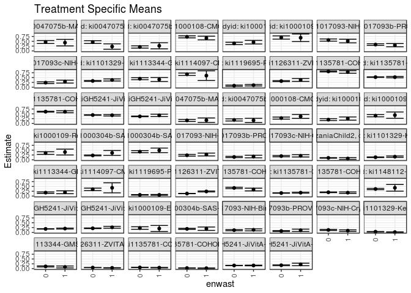

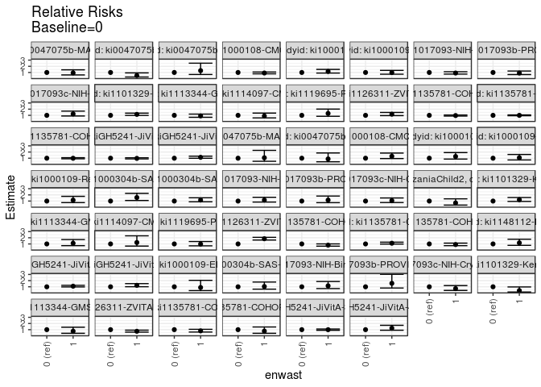

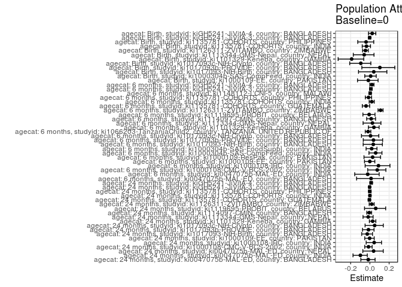

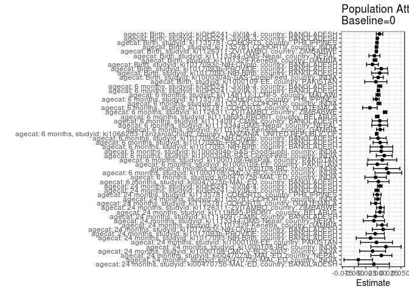

## Results Table

### Parameter: TSM

| agecat | studyid | country | intervention_level | baseline_level | estimate | ci_lower | ci_upper |
| --- | --- | --- | --- | --- | --- | --- | --- |
| Birth | ki1000109-EE | PAKISTAN | 0 | NA | 0.2258065 | 0.1598002 | 0.2918127 |
| Birth | ki1000109-EE | PAKISTAN | 1 | NA | 0.2000000 | 0.0427655 | 0.3572345 |
| Birth | ki1000304b-SAS-CompFeed | INDIA | 0 | NA | 0.1813263 | 0.1553298 | 0.2073229 |
| Birth | ki1000304b-SAS-CompFeed | INDIA | 1 | NA | 0.1895921 | 0.1013926 | 0.2777916 |
| Birth | ki1017093-NIH-Birth | BANGLADESH | 0 | NA | 0.1141596 | 0.0832479 | 0.1450713 |
| Birth | ki1017093-NIH-Birth | BANGLADESH | 1 | NA | 0.1318141 | 0.0802867 | 0.1833415 |
| Birth | ki1017093b-PROVIDE | BANGLADESH | 0 | NA | 0.0690756 | 0.0447115 | 0.0934397 |
| Birth | ki1017093b-PROVIDE | BANGLADESH | 1 | NA | 0.1076437 | 0.0473454 | 0.1679420 |
| Birth | ki1017093c-NIH-Crypto | BANGLADESH | 0 | NA | 0.1258610 | 0.0976233 | 0.1540987 |
| Birth | ki1017093c-NIH-Crypto | BANGLADESH | 1 | NA | 0.0885871 | 0.0460427 | 0.1311314 |
| Birth | ki1101329-Keneba | GAMBIA | 0 | NA | 0.0335753 | 0.0229364 | 0.0442142 |
| Birth | ki1101329-Keneba | GAMBIA | 1 | NA | 0.0129534 | 0.0016694 | 0.0242373 |
| Birth | ki1113344-GMS-Nepal | NEPAL | 0 | NA | 0.1166249 | 0.0886796 | 0.1445702 |
| Birth | ki1113344-GMS-Nepal | NEPAL | 1 | NA | 0.0880130 | 0.0383565 | 0.1376695 |
| Birth | ki1126311-ZVITAMBO | ZIMBABWE | 0 | NA | 0.0554661 | 0.0511559 | 0.0597762 |
| Birth | ki1126311-ZVITAMBO | ZIMBABWE | 1 | NA | 0.0409568 | 0.0326191 | 0.0492946 |
| Birth | ki1135781-COHORTS | INDIA | 0 | NA | 0.0639949 | 0.0572656 | 0.0707241 |
| Birth | ki1135781-COHORTS | INDIA | 1 | NA | 0.0514576 | 0.0384411 | 0.0644741 |
| Birth | ki1135781-COHORTS | PHILIPPINES | 0 | NA | 0.0307277 | 0.0238899 | 0.0375655 |
| Birth | ki1135781-COHORTS | PHILIPPINES | 1 | NA | 0.0235276 | 0.0097232 | 0.0373320 |
| Birth | kiGH5241-JiVitA-3 | BANGLADESH | 0 | NA | 0.1661938 | 0.1598462 | 0.1725414 |
| Birth | kiGH5241-JiVitA-3 | BANGLADESH | 1 | NA | 0.1654793 | 0.1482516 | 0.1827070 |
| Birth | kiGH5241-JiVitA-4 | BANGLADESH | 0 | NA | 0.1761526 | 0.1573115 | 0.1949937 |
| Birth | kiGH5241-JiVitA-4 | BANGLADESH | 1 | NA | 0.2190490 | 0.1534468 | 0.2846512 |
| 6 months | ki0047075b-MAL-ED | BANGLADESH | 0 | NA | 0.1595745 | 0.1071117 | 0.2120372 |
| 6 months | ki0047075b-MAL-ED | BANGLADESH | 1 | NA | 0.1707317 | 0.0553037 | 0.2861597 |
| 6 months | ki0047075b-MAL-ED | INDIA | 0 | NA | 0.1851852 | 0.1296859 | 0.2406845 |
| 6 months | ki0047075b-MAL-ED | INDIA | 1 | NA | 0.1627907 | 0.0522089 | 0.2733725 |
| 6 months | ki1000108-CMC-V-BCS-2002 | INDIA | 0 | NA | 0.2798606 | 0.2264665 | 0.3332548 |
| 6 months | ki1000108-CMC-V-BCS-2002 | INDIA | 1 | NA | 0.3676921 | 0.2677883 | 0.4675960 |

[output cut: 78 more lines]

### Parameter: E(Y)

| agecat | studyid | country | intervention_level | baseline_level | estimate | ci_lower | ci_upper |
| --- | --- | --- | --- | --- | --- | --- | --- |
| Birth | ki1000109-EE | PAKISTAN | NA | NA | 0.2222222 | 0.1613186 | 0.2831258 |
| Birth | ki1000304b-SAS-CompFeed | INDIA | NA | NA | 0.1828054 | 0.1605315 | 0.2050793 |
| Birth | ki1017093-NIH-Birth | BANGLADESH | NA | NA | 0.1189655 | 0.0925952 | 0.1453359 |
| Birth | ki1017093b-PROVIDE | BANGLADESH | NA | NA | 0.0770677 | 0.0543836 | 0.0997518 |
| Birth | ki1017093c-NIH-Crypto | BANGLADESH | NA | NA | 0.1150070 | 0.0915734 | 0.1384407 |
| Birth | ki1101329-Keneba | GAMBIA | NA | NA | 0.0282258 | 0.0198080 | 0.0366436 |
| Birth | ki1113344-GMS-Nepal | NEPAL | NA | NA | 0.1100775 | 0.0859045 | 0.1342505 |
| Birth | ki1126311-ZVITAMBO | ZIMBABWE | NA | NA | 0.0530095 | 0.0491714 | 0.0568475 |
| Birth | ki1135781-COHORTS | INDIA | NA | NA | 0.0617878 | 0.0558091 | 0.0677665 |
| Birth | ki1135781-COHORTS | PHILIPPINES | NA | NA | 0.0295533 | 0.0233992 | 0.0357074 |
| Birth | kiGH5241-JiVitA-3 | BANGLADESH | NA | NA | 0.1657624 | 0.1596821 | 0.1718426 |
| Birth | kiGH5241-JiVitA-4 | BANGLADESH | NA | NA | 0.1804919 | 0.1622043 | 0.1987794 |
| 6 months | ki0047075b-MAL-ED | BANGLADESH | NA | NA | 0.1615721 | 0.1137975 | 0.2093466 |
| 6 months | ki0047075b-MAL-ED | INDIA | NA | NA | 0.1810345 | 0.1313803 | 0.2306886 |
| 6 months | ki1000108-CMC-V-BCS-2002 | INDIA | NA | NA | 0.3030303 | 0.2556886 | 0.3503720 |
| 6 months | ki1000108-IRC | INDIA | NA | NA | 0.2198953 | 0.1783071 | 0.2614835 |
| 6 months | ki1000109-EE | PAKISTAN | NA | NA | 0.4041096 | 0.3477284 | 0.4604908 |
| 6 months | ki1000109-ResPak | PAKISTAN | NA | NA | 0.3596491 | 0.2972205 | 0.4220777 |
| 6 months | ki1000304b-SAS-CompFeed | INDIA | NA | NA | 0.2407255 | 0.2138448 | 0.2676061 |
| 6 months | ki1000304b-SAS-FoodSuppl | INDIA | NA | NA | 0.4289474 | 0.3791199 | 0.4787748 |
| 6 months | ki1017093-NIH-Birth | BANGLADESH | NA | NA | 0.2431907 | 0.2060665 | 0.2803148 |
| 6 months | ki1017093b-PROVIDE | BANGLADESH | NA | NA | 0.1507538 | 0.1220277 | 0.1794798 |
| 6 months | ki1017093c-NIH-Crypto | BANGLADESH | NA | NA | 0.1930836 | 0.1636957 | 0.2224715 |
| 6 months | ki1066203-TanzaniaChild2 | TANZANIA, UNITED REPUBLIC OF | NA | NA | 0.0960396 | 0.0831873 | 0.1088919 |
| 6 months | ki1101329-Keneba | GAMBIA | NA | NA | 0.1375062 | 0.1225178 | 0.1524945 |
| 6 months | ki1113344-GMS-Nepal | NEPAL | NA | NA | 0.1837121 | 0.1506498 | 0.2167744 |
| 6 months | ki1114097-CMIN | BANGLADESH | NA | NA | 0.3534483 | 0.2918020 | 0.4150945 |
| 6 months | ki1119695-PROBIT | BELARUS | NA | NA | 0.0625873 | 0.0488338 | 0.0763408 |
| 6 months | ki1126311-ZVITAMBO | ZIMBABWE | NA | NA | 0.1466846 | 0.1390145 | 0.1543548 |
| 6 months | ki1135781-COHORTS | GUATEMALA | NA | NA | 0.4062153 | 0.3741290 | 0.4383016 |
| 6 months | ki1135781-COHORTS | INDIA | NA | NA | 0.1611862 | 0.1522521 | 0.1701204 |
| 6 months | ki1135781-COHORTS | PHILIPPINES | NA | NA | 0.1932125 | 0.1780130 | 0.2084119 |
| 6 months | ki1148112-LCNI-5 | MALAWI | NA | NA | 0.3682956 | 0.3356382 | 0.4009530 |
| 6 months | kiGH5241-JiVitA-3 | BANGLADESH | NA | NA | 0.1814799 | 0.1738720 | 0.1890878 |
| 6 months | kiGH5241-JiVitA-4 | BANGLADESH | NA | NA | 0.2158730 | 0.2021674 | 0.2295786 |
| 24 months | ki0047075b-MAL-ED | BANGLADESH | NA | NA | 0.4527363 | 0.3837514 | 0.5217212 |
| 24 months | ki0047075b-MAL-ED | INDIA | NA | NA | 0.4170404 | 0.3521799 | 0.4819008 |
| 24 months | ki0047075b-MAL-ED | NEPAL | NA | NA | 0.2133333 | 0.1596859 | 0.2669808 |
| 24 months | ki1000108-CMC-V-BCS-2002 | INDIA | NA | NA | 0.7197802 | 0.6735800 | 0.7659804 |
| 24 months | ki1000108-IRC | INDIA | NA | NA | 0.4073107 | 0.3580395 | 0.4565819 |
| 24 months | ki1000109-EE | PAKISTAN | NA | NA | 0.6934307 | 0.6159409 | 0.7709205 |
| 24 months | ki1017093-NIH-Birth | BANGLADESH | NA | NA | 0.5476773 | 0.4993820 | 0.5959725 |
| 24 months | ki1017093b-PROVIDE | BANGLADESH | NA | NA | 0.3245614 | 0.2860904 | 0.3630324 |
| 24 months | ki1017093c-NIH-Crypto | BANGLADESH | NA | NA | 0.2480000 | 0.2101093 | 0.2858907 |
| 24 months | ki1101329-Keneba | GAMBIA | NA | NA | 0.3351222 | 0.3125235 | 0.3577210 |
| 24 months | ki1113344-GMS-Nepal | NEPAL | NA | NA | 0.4329670 | 0.3873894 | 0.4785447 |
| 24 months | ki1114097-CMIN | BANGLADESH | NA | NA | 0.6681034 | 0.6073788 | 0.7288281 |
| 24 months | ki1119695-PROBIT | BELARUS | NA | NA | 0.0850694 | 0.0559313 | 0.1142076 |
| 24 months | ki1126311-ZVITAMBO | ZIMBABWE | NA | NA | 0.3235880 | 0.2999438 | 0.3472323 |
| 24 months | ki1135781-COHORTS | GUATEMALA | NA | NA | 0.8130477 | 0.7891917 | 0.8369037 |
| 24 months | ki1135781-COHORTS | INDIA | NA | NA | 0.5218935 | 0.5081423 | 0.5356447 |
| 24 months | ki1135781-COHORTS | PHILIPPINES | NA | NA | 0.6131231 | 0.5934151 | 0.6328312 |
| 24 months | kiGH5241-JiVitA-3 | BANGLADESH | NA | NA | 0.4385529 | 0.4244156 | 0.4526902 |
| 24 months | kiGH5241-JiVitA-4 | BANGLADESH | NA | NA | 0.3733488 | 0.3557063 | 0.3909913 |

### Parameter: RR

| agecat | studyid | country | intervention_level | baseline_level | estimate | ci_lower | ci_upper |
| --- | --- | --- | --- | --- | --- | --- | --- |
| Birth | ki1000109-EE | PAKISTAN | 0 | 0 | 1.0000000 | 1.0000000 | 1.0000000 |
| Birth | ki1000109-EE | PAKISTAN | 1 | 0 | 0.8857143 | 0.3828476 | 2.0490918 |
| Birth | ki1000304b-SAS-CompFeed | INDIA | 0 | 0 | 1.0000000 | 1.0000000 | 1.0000000 |
| Birth | ki1000304b-SAS-CompFeed | INDIA | 1 | 0 | 1.0455850 | 0.6186623 | 1.7671162 |
| Birth | ki1017093-NIH-Birth | BANGLADESH | 0 | 0 | 1.0000000 | 1.0000000 | 1.0000000 |
| Birth | ki1017093-NIH-Birth | BANGLADESH | 1 | 0 | 1.1546476 | 0.7174647 | 1.8582252 |
| Birth | ki1017093b-PROVIDE | BANGLADESH | 0 | 0 | 1.0000000 | 1.0000000 | 1.0000000 |
| Birth | ki1017093b-PROVIDE | BANGLADESH | 1 | 0 | 1.5583463 | 0.8035338 | 3.0222039 |
| Birth | ki1017093c-NIH-Crypto | BANGLADESH | 0 | 0 | 1.0000000 | 1.0000000 | 1.0000000 |
| Birth | ki1017093c-NIH-Crypto | BANGLADESH | 1 | 0 | 0.7038484 | 0.4136711 | 1.1975758 |
| Birth | ki1101329-Keneba | GAMBIA | 0 | 0 | 1.0000000 | 1.0000000 | 1.0000000 |
| Birth | ki1101329-Keneba | GAMBIA | 1 | 0 | 0.3858003 | 0.1526824 | 0.9748462 |
| Birth | ki1113344-GMS-Nepal | NEPAL | 0 | 0 | 1.0000000 | 1.0000000 | 1.0000000 |
| Birth | ki1113344-GMS-Nepal | NEPAL | 1 | 0 | 0.7546674 | 0.4084898 | 1.3942158 |
| Birth | ki1126311-ZVITAMBO | ZIMBABWE | 0 | 0 | 1.0000000 | 1.0000000 | 1.0000000 |
| Birth | ki1126311-ZVITAMBO | ZIMBABWE | 1 | 0 | 0.7384128 | 0.5938750 | 0.9181282 |
| Birth | ki1135781-COHORTS | INDIA | 0 | 0 | 1.0000000 | 1.0000000 | 1.0000000 |
| Birth | ki1135781-COHORTS | INDIA | 1 | 0 | 0.8040888 | 0.6116601 | 1.0570557 |
| Birth | ki1135781-COHORTS | PHILIPPINES | 0 | 0 | 1.0000000 | 1.0000000 | 1.0000000 |
| Birth | ki1135781-COHORTS | PHILIPPINES | 1 | 0 | 0.7656805 | 0.4088761 | 1.4338491 |
| Birth | kiGH5241-JiVitA-3 | BANGLADESH | 0 | 0 | 1.0000000 | 1.0000000 | 1.0000000 |
| Birth | kiGH5241-JiVitA-3 | BANGLADESH | 1 | 0 | 0.9957010 | 0.8934857 | 1.1096098 |
| Birth | kiGH5241-JiVitA-4 | BANGLADESH | 0 | 0 | 1.0000000 | 1.0000000 | 1.0000000 |
| Birth | kiGH5241-JiVitA-4 | BANGLADESH | 1 | 0 | 1.2435184 | 0.9060042 | 1.7067669 |
| 6 months | ki0047075b-MAL-ED | BANGLADESH | 0 | 0 | 1.0000000 | 1.0000000 | 1.0000000 |
| 6 months | ki0047075b-MAL-ED | BANGLADESH | 1 | 0 | 1.0699187 | 0.5044964 | 2.2690470 |
| 6 months | ki0047075b-MAL-ED | INDIA | 0 | 0 | 1.0000000 | 1.0000000 | 1.0000000 |
| 6 months | ki0047075b-MAL-ED | INDIA | 1 | 0 | 0.8790698 | 0.4183849 | 1.8470161 |
| 6 months | ki1000108-CMC-V-BCS-2002 | INDIA | 0 | 0 | 1.0000000 | 1.0000000 | 1.0000000 |
| 6 months | ki1000108-CMC-V-BCS-2002 | INDIA | 1 | 0 | 1.3138402 | 0.9430102 | 1.8304954 |

[output cut: 78 more lines]

### Parameter: PAR

| agecat | studyid | country | intervention_level | baseline_level | estimate | ci_lower | ci_upper |
| --- | --- | --- | --- | --- | --- | --- | --- |
| Birth | ki1000109-EE | PAKISTAN | 0 | NA | -0.0035842 | -0.0273046 | 0.0201362 |
| Birth | ki1000304b-SAS-CompFeed | INDIA | 0 | NA | 0.0014791 | -0.0093882 | 0.0123464 |
| Birth | ki1017093-NIH-Birth | BANGLADESH | 0 | NA | 0.0048059 | -0.0126704 | 0.0222822 |
| Birth | ki1017093b-PROVIDE | BANGLADESH | 0 | NA | 0.0079921 | -0.0053037 | 0.0212879 |
| Birth | ki1017093c-NIH-Crypto | BANGLADESH | 0 | NA | -0.0108540 | -0.0235959 | 0.0018879 |
| Birth | ki1101329-Keneba | GAMBIA | 0 | NA | -0.0053495 | -0.0093987 | -0.0013003 |
| Birth | ki1113344-GMS-Nepal | NEPAL | 0 | NA | -0.0065474 | -0.0184235 | 0.0053287 |
| Birth | ki1126311-ZVITAMBO | ZIMBABWE | 0 | NA | -0.0024566 | -0.0040380 | -0.0008752 |
| Birth | ki1135781-COHORTS | INDIA | 0 | NA | -0.0022070 | -0.0048800 | 0.0004660 |
| Birth | ki1135781-COHORTS | PHILIPPINES | 0 | NA | -0.0011744 | -0.0036407 | 0.0012918 |
| Birth | kiGH5241-JiVitA-3 | BANGLADESH | 0 | NA | -0.0004314 | -0.0024145 | 0.0015517 |
| Birth | kiGH5241-JiVitA-4 | BANGLADESH | 0 | NA | 0.0043393 | -0.0025624 | 0.0112409 |
| 6 months | ki0047075b-MAL-ED | BANGLADESH | 0 | NA | 0.0019976 | -0.0207098 | 0.0247049 |
| 6 months | ki0047075b-MAL-ED | INDIA | 0 | NA | -0.0041507 | -0.0271104 | 0.0188090 |
| 6 months | ki1000108-CMC-V-BCS-2002 | INDIA | 0 | NA | 0.0231697 | -0.0054307 | 0.0517701 |
| 6 months | ki1000108-IRC | INDIA | 0 | NA | 0.0195258 | -0.0088622 | 0.0479138 |
| 6 months | ki1000109-EE | PAKISTAN | 0 | NA | -0.0003784 | -0.0220206 | 0.0212637 |
| 6 months | ki1000109-ResPak | PAKISTAN | 0 | NA | 0.0102557 | -0.0206547 | 0.0411661 |
| 6 months | ki1000304b-SAS-CompFeed | INDIA | 0 | NA | 0.0144820 | -0.0025564 | 0.0315204 |
| 6 months | ki1000304b-SAS-FoodSuppl | INDIA | 0 | NA | 0.0079570 | -0.0162682 | 0.0321823 |
| 6 months | ki1017093-NIH-Birth | BANGLADESH | 0 | NA | 0.0085374 | -0.0157090 | 0.0327838 |
| 6 months | ki1017093b-PROVIDE | BANGLADESH | 0 | NA | 0.0055845 | -0.0095664 | 0.0207354 |
| 6 months | ki1017093c-NIH-Crypto | BANGLADESH | 0 | NA | 0.0012801 | -0.0160403 | 0.0186005 |
| 6 months | ki1066203-TanzaniaChild2 | TANZANIA, UNITED REPUBLIC OF | 0 | NA | -0.0018036 | -0.0045870 | 0.0009797 |
| 6 months | ki1101329-Keneba | GAMBIA | 0 | NA | 0.0057217 | -0.0019363 | 0.0133797 |
| 6 months | ki1113344-GMS-Nepal | NEPAL | 0 | NA | 0.0048428 | -0.0121878 | 0.0218735 |
| 6 months | ki1114097-CMIN | BANGLADESH | 0 | NA | 0.0048244 | -0.0114980 | 0.0211468 |
| 6 months | ki1119695-PROBIT | BELARUS | 0 | NA | -0.0004904 | -0.0044348 | 0.0034540 |
| 6 months | ki1126311-ZVITAMBO | ZIMBABWE | 0 | NA | 0.0162741 | 0.0123771 | 0.0201711 |
| 6 months | ki1135781-COHORTS | GUATEMALA | 0 | NA | -0.0162241 | -0.0317704 | -0.0006778 |
| 6 months | ki1135781-COHORTS | INDIA | 0 | NA | 0.0031012 | -0.0011385 | 0.0073409 |
| 6 months | ki1135781-COHORTS | PHILIPPINES | 0 | NA | -0.0028123 | -0.0090952 | 0.0034707 |
| 6 months | ki1148112-LCNI-5 | MALAWI | 0 | NA | 0.0010229 | -0.0034161 | 0.0054618 |
| 6 months | kiGH5241-JiVitA-3 | BANGLADESH | 0 | NA | 0.0018393 | -0.0006285 | 0.0043072 |
| 6 months | kiGH5241-JiVitA-4 | BANGLADESH | 0 | NA | 0.0045984 | -0.0000002 | 0.0091969 |
| 24 months | ki0047075b-MAL-ED | BANGLADESH | 0 | NA | -0.0078055 | -0.0412493 | 0.0256383 |
| 24 months | ki0047075b-MAL-ED | INDIA | 0 | NA | -0.0411615 | -0.0717266 | -0.0105963 |
| 24 months | ki0047075b-MAL-ED | NEPAL | 0 | NA | 0.0082051 | -0.0144227 | 0.0308329 |
| 24 months | ki1000108-CMC-V-BCS-2002 | INDIA | 0 | NA | -0.0104386 | -0.0381404 | 0.0172631 |
| 24 months | ki1000108-IRC | INDIA | 0 | NA | 0.0180903 | -0.0143842 | 0.0505648 |
| 24 months | ki1000109-EE | PAKISTAN | 0 | NA | -0.0022215 | -0.0364043 | 0.0319613 |
| 24 months | ki1017093-NIH-Birth | BANGLADESH | 0 | NA | -0.0150323 | -0.0457005 | 0.0156360 |
| 24 months | ki1017093b-PROVIDE | BANGLADESH | 0 | NA | -0.0049205 | -0.0243962 | 0.0145551 |
| 24 months | ki1017093c-NIH-Crypto | BANGLADESH | 0 | NA | 0.0122059 | -0.0111851 | 0.0355969 |
| 24 months | ki1101329-Keneba | GAMBIA | 0 | NA | 0.0096566 | -0.0016031 | 0.0209164 |
| 24 months | ki1113344-GMS-Nepal | NEPAL | 0 | NA | -0.0076954 | -0.0303388 | 0.0149481 |
| 24 months | ki1114097-CMIN | BANGLADESH | 0 | NA | -0.0047076 | -0.0214330 | 0.0120178 |
| 24 months | ki1119695-PROBIT | BELARUS | 0 | NA | 0.0051554 | -0.0037656 | 0.0140763 |
| 24 months | ki1126311-ZVITAMBO | ZIMBABWE | 0 | NA | 0.0061076 | -0.0022645 | 0.0144797 |
| 24 months | ki1135781-COHORTS | GUATEMALA | 0 | NA | -0.0040355 | -0.0144211 | 0.0063500 |
| 24 months | ki1135781-COHORTS | INDIA | 0 | NA | 0.0001561 | -0.0057335 | 0.0060457 |
| 24 months | ki1135781-COHORTS | PHILIPPINES | 0 | NA | -0.0005517 | -0.0088724 | 0.0077689 |
| 24 months | kiGH5241-JiVitA-3 | BANGLADESH | 0 | NA | -0.0010822 | -0.0055681 | 0.0034037 |
| 24 months | kiGH5241-JiVitA-4 | BANGLADESH | 0 | NA | 0.0049531 | -0.0000528 | 0.0099589 |

### Parameter: PAF

| agecat | studyid | country | intervention_level | baseline_level | estimate | ci_lower | ci_upper |
| --- | --- | --- | --- | --- | --- | --- | --- |
| Birth | ki1000109-EE | PAKISTAN | 0 | NA | -0.0161290 | -0.1286362 | 0.0851629 |
| Birth | ki1000304b-SAS-CompFeed | INDIA | 0 | NA | 0.0080910 | -0.0533155 | 0.0659176 |
| Birth | ki1017093-NIH-Birth | BANGLADESH | 0 | NA | 0.0403976 | -0.1181508 | 0.1764647 |
| Birth | ki1017093b-PROVIDE | BANGLADESH | 0 | NA | 0.1037021 | -0.0838045 | 0.2587686 |
| Birth | ki1017093c-NIH-Crypto | BANGLADESH | 0 | NA | -0.0943768 | -0.2097531 | 0.0099958 |
| Birth | ki1101329-Keneba | GAMBIA | 0 | NA | -0.1895255 | -0.3298960 | -0.0639712 |
| Birth | ki1113344-GMS-Nepal | NEPAL | 0 | NA | -0.0594797 | -0.1725275 | 0.0426688 |
| Birth | ki1126311-ZVITAMBO | ZIMBABWE | 0 | NA | -0.0463423 | -0.0764145 | -0.0171102 |
| Birth | ki1135781-COHORTS | INDIA | 0 | NA | -0.0357197 | -0.0797706 | 0.0065342 |
| Birth | ki1135781-COHORTS | PHILIPPINES | 0 | NA | -0.0397398 | -0.1262481 | 0.0401237 |
| Birth | kiGH5241-JiVitA-3 | BANGLADESH | 0 | NA | -0.0026025 | -0.0146408 | 0.0092929 |
| Birth | kiGH5241-JiVitA-4 | BANGLADESH | 0 | NA | 0.0240413 | -0.0147643 | 0.0613629 |
| 6 months | ki0047075b-MAL-ED | BANGLADESH | 0 | NA | 0.0123634 | -0.1386338 | 0.1433365 |
| 6 months | ki0047075b-MAL-ED | INDIA | 0 | NA | -0.0229277 | -0.1578533 | 0.0962749 |
| 6 months | ki1000108-CMC-V-BCS-2002 | INDIA | 0 | NA | 0.0764599 | -0.0227322 | 0.1660317 |
| 6 months | ki1000108-IRC | INDIA | 0 | NA | 0.0887960 | -0.0493490 | 0.2087544 |
| 6 months | ki1000109-EE | PAKISTAN | 0 | NA | -0.0009365 | -0.0559508 | 0.0512116 |
| 6 months | ki1000109-ResPak | PAKISTAN | 0 | NA | 0.0285159 | -0.0613641 | 0.1107846 |
| 6 months | ki1000304b-SAS-CompFeed | INDIA | 0 | NA | 0.0601599 | -0.0099636 | 0.1254146 |
| 6 months | ki1000304b-SAS-FoodSuppl | INDIA | 0 | NA | 0.0185501 | -0.0395947 | 0.0734429 |
| 6 months | ki1017093-NIH-Birth | BANGLADESH | 0 | NA | 0.0351058 | -0.0698303 | 0.1297491 |
| 6 months | ki1017093b-PROVIDE | BANGLADESH | 0 | NA | 0.0370438 | -0.0688246 | 0.1324258 |
| 6 months | ki1017093c-NIH-Crypto | BANGLADESH | 0 | NA | 0.0066297 | -0.0872583 | 0.0924101 |
| 6 months | ki1066203-TanzaniaChild2 | TANZANIA, UNITED REPUBLIC OF | 0 | NA | -0.0187801 | -0.0480893 | 0.0097095 |
| 6 months | ki1101329-Keneba | GAMBIA | 0 | NA | 0.0416107 | -0.0156094 | 0.0956069 |
| 6 months | ki1113344-GMS-Nepal | NEPAL | 0 | NA | 0.0263610 | -0.0708496 | 0.1147470 |
| 6 months | ki1114097-CMIN | BANGLADESH | 0 | NA | 0.0136496 | -0.0336341 | 0.0587702 |
| 6 months | ki1119695-PROBIT | BELARUS | 0 | NA | -0.0078353 | -0.0727195 | 0.0531243 |
| 6 months | ki1126311-ZVITAMBO | ZIMBABWE | 0 | NA | 0.1109463 | 0.0843952 | 0.1367274 |
| 6 months | ki1135781-COHORTS | GUATEMALA | 0 | NA | -0.0399397 | -0.0789805 | -0.0023114 |
| 6 months | ki1135781-COHORTS | INDIA | 0 | NA | 0.0192398 | -0.0074062 | 0.0451810 |
| 6 months | ki1135781-COHORTS | PHILIPPINES | 0 | NA | -0.0145554 | -0.0475848 | 0.0174327 |
| 6 months | ki1148112-LCNI-5 | MALAWI | 0 | NA | 0.0027773 | -0.0093645 | 0.0147730 |
| 6 months | kiGH5241-JiVitA-3 | BANGLADESH | 0 | NA | 0.0101352 | -0.0035204 | 0.0236050 |
| 6 months | kiGH5241-JiVitA-4 | BANGLADESH | 0 | NA | 0.0213012 | -0.0002885 | 0.0424249 |
| 24 months | ki0047075b-MAL-ED | BANGLADESH | 0 | NA | -0.0172408 | -0.0938915 | 0.0540388 |
| 24 months | ki0047075b-MAL-ED | INDIA | 0 | NA | -0.0986991 | -0.1755082 | -0.0269087 |
| 24 months | ki0047075b-MAL-ED | NEPAL | 0 | NA | 0.0384615 | -0.0734418 | 0.1386992 |
| 24 months | ki1000108-CMC-V-BCS-2002 | INDIA | 0 | NA | -0.0145025 | -0.0537844 | 0.0233150 |
| 24 months | ki1000108-IRC | INDIA | 0 | NA | 0.0444139 | -0.0388109 | 0.1209712 |
| 24 months | ki1000109-EE | PAKISTAN | 0 | NA | -0.0032037 | -0.0537349 | 0.0449044 |
| 24 months | ki1017093-NIH-Birth | BANGLADESH | 0 | NA | -0.0274473 | -0.0850866 | 0.0271302 |
| 24 months | ki1017093b-PROVIDE | BANGLADESH | 0 | NA | -0.0151606 | -0.0769703 | 0.0431018 |
| 24 months | ki1017093c-NIH-Crypto | BANGLADESH | 0 | NA | 0.0492173 | -0.0500239 | 0.1390790 |
| 24 months | ki1101329-Keneba | GAMBIA | 0 | NA | 0.0288153 | -0.0053667 | 0.0618351 |
| 24 months | ki1113344-GMS-Nepal | NEPAL | 0 | NA | -0.0177736 | -0.0714647 | 0.0332271 |
| 24 months | ki1114097-CMIN | BANGLADESH | 0 | NA | -0.0070462 | -0.0324198 | 0.0177037 |
| 24 months | ki1119695-PROBIT | BELARUS | 0 | NA | 0.0606020 | -0.0557052 | 0.1640957 |
| 24 months | ki1126311-ZVITAMBO | ZIMBABWE | 0 | NA | 0.0188746 | -0.0073442 | 0.0444110 |
| 24 months | ki1135781-COHORTS | GUATEMALA | 0 | NA | -0.0049635 | -0.0178249 | 0.0077354 |
| 24 months | ki1135781-COHORTS | INDIA | 0 | NA | 0.0002991 | -0.0110498 | 0.0115207 |
| 24 months | ki1135781-COHORTS | PHILIPPINES | 0 | NA | -0.0008999 | -0.0145634 | 0.0125797 |
| 24 months | kiGH5241-JiVitA-3 | BANGLADESH | 0 | NA | -0.0024676 | -0.0127490 | 0.0077094 |
| 24 months | kiGH5241-JiVitA-4 | BANGLADESH | 0 | NA | 0.0132667 | -0.0002548 | 0.0266053 |